# Midterm 2

Published

November 7, 2025

# Problem 1

```python
x = "omen"
y = 5

def mystery(y, z="odor"):

    def enigma(y):
        return (y + len(x)) % len(z)

    def puzzle(z):
        return (z + x)[i::y]

    s = ""
    for i in range(2):
        s += puzzle(z)
        if i % 2 == 1:
            s += z[enigma(y)]
        y -= 1
    return s

print(mystery(z="clay", y=y-1))
```

Solution: Provide 3x3 grid of blank spaces.

# Problem 2

In this problem you will write a program to create a bank of interactive “buttons” which will toggle through two different states when pressed. You should initially lay out a grid of circles that completely fills the window, according to the window dimensions and desired number of rows and columns in the starting template. These circles should be initially filled and black. So a starting state for 3 columns and 2 rows might look like:

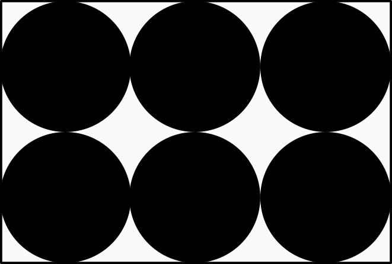

One possible initial grid of circles

Then, when one of the circles is clicked, you want to shrink that circle to half its original size and turn it red, as shown below.

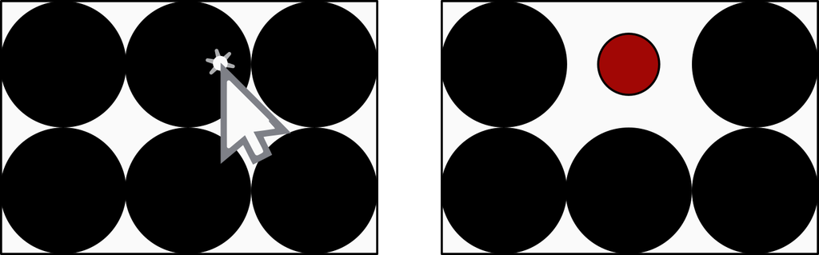

Clicking a circle should make it half its original size and red

Clicking on a small red circle should turn the circle black and return it to its original size. Clicking each circle then would turn them all small and red, and then clicking each again would turn them all back to black and the original size.

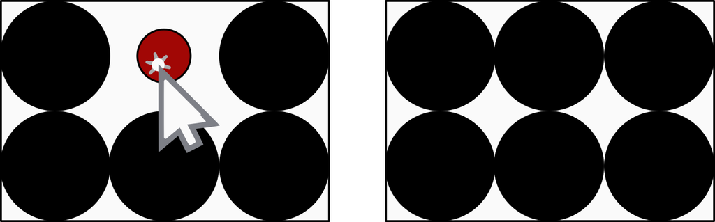

Clicking a small red circle turns it black and returns it to its original size

I have provided some imports and defined constants below to get you started, which you should absolutely use in the course of writing your program.

```python
from pgl import GWindow, GOval

ROWS = 2
COLS = 3
GRID_SIZE = 200
GW_WIDTH = COLS * GRID_SIZE
GW_HEIGHT = ROWS * GRID_SIZE
```

**TipA Solution**

```python
from pgl import GWindow, GOval

ROWS = 2
COLS = 3
GRID_SIZE = 200
GW_WIDTH = COLS * GRID_SIZE
GW_HEIGHT = ROWS * GRID_SIZE

gw = GWindow(GW_WIDTH, GW_HEIGHT)

for i in range(ROWS):
    for j in range(COLS):
        circ = GOval(j*GRID_SIZE, i*GRID_SIZE, GRID_SIZE, GRID_SIZE)
        circ.set_filled(True)
        gw.add(circ)

def click_action(e):
    mx, my = e.get_x(), e.get_y()
    this_circ = gw.get_element_at(mx, my)

    if this_circ is not None:
        size = this_circ.get_width()
        x = this_circ.get_x()
        y = this_circ.get_y()
        if size == 200:
            this_circ.set_fill_color('red')
            this_circ.set_bounds(
                x + GRID_SIZE / 4,
                y + GRID_SIZE / 4,
                GRID_SIZE / 2,
                GRID_SIZE / 2
            )
        else:
            this_circ.set_fill_color('black')
            this_circ.set_bounds(
                x - GRID_SIZE / 4,
                y - GRID_SIZE / 4,
                GRID_SIZE,
                GRID_SIZE
            )

gw.add_event_listener("mousedown", click_action)
```

# Problem 3

Multidimensional arrays allow us to encode all manner of gridded data. One example might be the popular game Sudoku, wherein the digits 1-9 need to be placed onto a grid such that several conditions are upheld:

1. Each row has the numbers 1-9 appearing exactly once
2. Each column has the numbers 1-9 appearing exactly once
3. Each 3x3 mini-grid needs to have the numbers 1-9 appearing exactly once

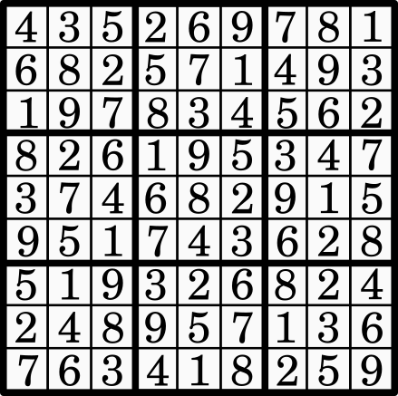

One slightly flawed Sudoku solution

While solving a Sudoku puzzle computationally can be quite difficult, verifying a solution is just a question of checking the above conditions. It is the last condition that you will focus on in this problem.

There are 9 possible 3x3 mini-grids that might need to be checked. Suppose we index the rows and columns of these mini-grids as usual, so that if I was talking about the (0,0) mini-grid, I’d be referring to the top left grid, whereas the (2,2) mini-grid would be the bottom right.

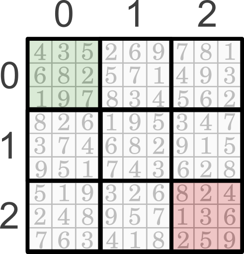

The mini-grid corresponding to (0,0) is valid and appears in the upper left, whereas the mini-grid for (2,2) is invalid and appears in the lower right

Your goal in this problem is to write a function called `check_mini_grid(puzzle, row_idx, col_idx)`, which takes as input the 2d-array representing the filled Sudoku puzzle, as well as the row index and column index of the mini-grid that you want to check. Then your function should return `True` or `False` depending on whether that 3x3 block of the puzzle meets the criteria of having each number 1-9 appearing exactly once.

In the example puzzle shown here, your function should be able to mimic the following:

```
>>> puzzle1 = [[4,3,5,2,6,9,7,8,1],
               [6,8,2,5,7,1,4,9,3],
               [1,9,7,8,3,4,5,6,2],
               [8,2,6,1,9,5,3,4,7],
               [3,7,4,6,8,2,9,1,5],
               [9,5,1,7,4,3,6,2,8],
               [5,1,9,3,2,6,8,2,4],
               [2,4,8,9,5,7,1,3,6],
               [7,6,3,4,1,8,2,5,9]]

>>> check_mini_grid(puzzle, 0, 0)
True
>>> check_mini_grid(puzzle, 2, 0)
True
>>> check_mini_grid(puzzle, 2, 2)
False
```

**TipA Solution**

```python
def check_mini_grid(puzzle, row_idx, col_idx):
    grid_vals = []
    for r in range(3):
        for c in range(3):
            grid_vals.append(puzzle[row_idx*3+r][col_idx*3+c])
    return sorted(grid_vals) == list(range(1,10))
```